# Homework 5

Elif Konyar - IE582 - Fall 2018

## Introduction

In this homework, we are asked to implement Multiple Instance Learning to the dataset Musk1. The dataset is read below. Since distance-related applications are performed, data is scaled beforehand. Then, distance matrices are formed:

```r
setwd("/Users/elifkonyar/Desktop/IE 582/HW5")
data<-fread("Musk1.csv")
data_distance<-data[,c(-1,-2)]
#dist matrix
scaled_data<-scale(data_distance)
dist_euc<-as.matrix(dist(scaled_data,"euclidean"))
dist_man<-as.matrix(dist(scaled_data,"manhattan"))
```

## K-MEDOIDS

As the first step, instances are clustered with K-medoids algorithm. For this step, 2 distance measures are used: Euclidean and Manhattan.

### Euclidean Case

In the clustering part, the first parameter to be decided on is the number of clusters, k. For this problem, different k values from 2 up to 15 are chosen as candidates. For each k value, total within sum of squares measure is calculated. Since k-medoids algorithm is used, the center in the clusters is also a point from the instance set.

```r
dist_euc_dt<-as.data.table(dist_euc)
k_max<-15
totwss <- rep(0, k_max-1)
sum<-0
for(i in 2:k_max){
  kmed <- pam(scaled_data,k=i,diss=FALSE,metric='euclidean')
  sum<-0
  for(z in 1:i){
    ins<-kmed$clustering==z
    ins<-dist_euc_dt[ins]
    med<-kmed$id.med[z]
    colname<-as.character(as.numeric(med))
    that_clus<-ins[,get(colname)]
    squared<-that_clus*that_clus
    sum<-sum+sum(squared)
  }
  totwss[i-1] <- sum
}
```

Afterwards, these total within ss values are plotted to capture the elbow point. From the plot below, k can be chosen as 6.

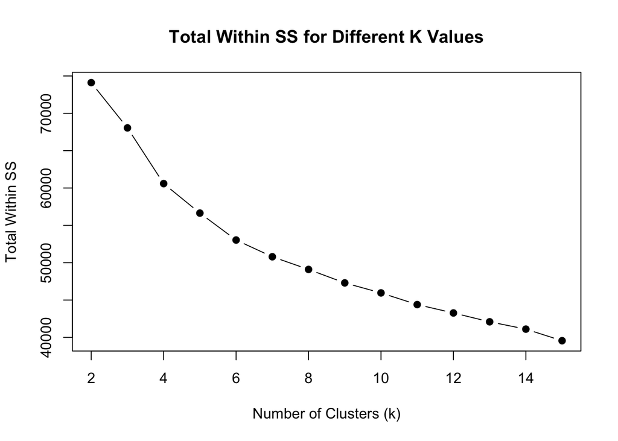

```r
# Plot
plot(2:k_max, totwss, type = "b", pch = 19,main="Total Within SS for Different K Values"
     ,xlab = "Number of Clusters (k)",ylab="Total Within SS")
```

```r
#k is chosen to be 6
```

As the next step, data is clustered such that 6 clusters are obtained. For each instance, distances to the centroids of 6 clusters are obtained from the distance matrix. Those values are stored in “table_med_euc” table.

```r
final_med_euc<-pam(scaled_data,k=6,diss=FALSE,metric='euclidean')
final_medoids_euc<-final_med_euc$id.med
table_med_euc<-dist_euc_dt[,get(as.character(as.numeric(final_medoids_euc[1])))]
for(i in 2:6){
  table_med_euc<-cbind(table_med_euc,dist_euc_dt[,get(as.character(as.numeric(final_medoids_euc[i])))])
}
table_med_euc<-as.data.table(table_med_euc)
setnames(table_med_euc,old=colnames(table_med_euc),new=c("C1","C2","C3","C4","C5","C6"))
baginfo<-data[,c(1,2)]
table_med_euc<-cbind(baginfo,table_med_euc)
setnames(table_med_euc,old=c("V1","V2"),new=c("BagClass","BagID"))
```

As the final step, the distances to each cluster centroid of the instances in each bag are averaged; so that bag representation is obtained in the “avg_table_med_euc” table.

```r
avg_table_med_euc<-table_med_euc[,.(C1=mean(C1),C2=mean(C2),C3=mean(C3),C4=mean(C4),C5=mean(C5),C6=mean(C6)),keyby=.(BagID)]
bagclass<-baginfo[!duplicated(baginfo),]
avg_table_med_euc<-cbind(bagclass$V1,avg_table_med_euc)
setnames(avg_table_med_euc,old="V1",new="BagClass")
```

### Manhattan Case

For the Manhattan case, the same steps are repeated. However, distance measure is converted to Manhattan distance.

```r
dist_man_dt<-as.data.table(dist_man)
totwss <- rep(0, k_max-1)
sum<-0
for(i in 2:k_max){
  kmed <- pam(scaled_data,k=i,diss=FALSE,metric='manhattan')
  sum<-0
  for(z in 1:i){
    ins<-kmed$clustering==z
    ins<-dist_man_dt[ins]
    med<-kmed$id.med[z]
    colname<-as.character(as.numeric(med))
    that_clus<-ins[,get(colname)]
    squared<-that_clus*that_clus
    sum<-sum+sum(squared)
  }
  totwss[i-1] <- sum
}
```

The plot of total within sum of squares for each k value is plotted below:

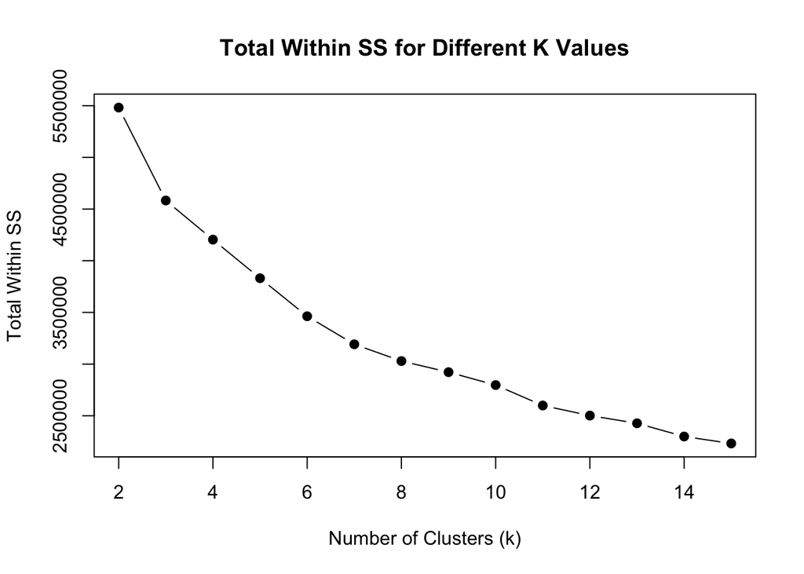

```r
# Plot
plot(2:k_max, totwss, type = "b", pch = 19,main="Total Within SS for Different K Values"
     ,xlab = "Number of Clusters (k)",ylab="Total Within SS")
```

```r
#k is chosen to be 7
```

From the plot above, k can be chosen as 7. Then, in order to obtain bag representation table, the same procedure is followed:

```r
final_med_man<-pam(scaled_data,k=7,diss=FALSE,metric='manhattan')
final_medoids_man<-final_med_man$id.med

table_med_man<-dist_man_dt[,get(as.character(as.numeric(final_medoids_man[1])))]
for(i in 2:7){
  table_med_man<-cbind(table_med_man,dist_man_dt[,get(as.character(as.numeric(final_medoids_man[i])))])
}
table_med_man<-as.data.table(table_med_man)
setnames(table_med_man,old=colnames(table_med_man),new=c("C1","C2","C3","C4","C5","C6","C7"))
baginfo<-data[,c(1,2)]
table_med_man<-cbind(baginfo,table_med_man)
setnames(table_med_man,old=c("V1","V2"),new=c("BagClass","BagID"))
```

```r
avg_table_med_man<-table_med_man[,.(C1=mean(C1),C2=mean(C2),C3=mean(C3),C4=mean(C4),C5=mean(C5),C6=mean(C6),C7=mean(C7)),keyby=.(BagID)]
bagclass<-baginfo[!duplicated(baginfo),]
avg_table_med_man<-cbind(bagclass$V1,avg_table_med_man)
setnames(avg_table_med_man,old="V1",new="BagClass")
```

## HIERARCHICAL CLUSTERING

In this part, instances are clustered hierarchically, instead of with k-medoids algorithm. Again 2 distance measures are used: Euclidean and Manhattan. In hierarchical clustering, 2 parameters are required to be determined: number of clusters and linkage type. Centroid, single and complete linkages are tried. However, complete linkage seemed to be the best to cluster these instances when looked at thi dendrogram.

### Euclidean Case

In this part, euclidean distance is used. At first, the same k value with the k-medoids euclidean distance case is used. However, some clusters had very few observations in that case. As an example, the sixth cluster had only 2 instances. Thus, I checked several different k values such that in none of the clusters, there are very few observations. Then, k is chosen as 3.

```r
hier_clus_euc<-hclust(dist(scaled_data,"euclidean"),method="centroid")
#bad
hier_clus_euc<-hclust(dist(scaled_data,"euclidean"),method="complete")
hier_clus_euc
```

```
##
## Call:
## hclust(d = dist(scaled_data, "euclidean"), method = "complete")
##
## Cluster method   : complete
## Distance         : euclidean
## Number of objects: 476
```

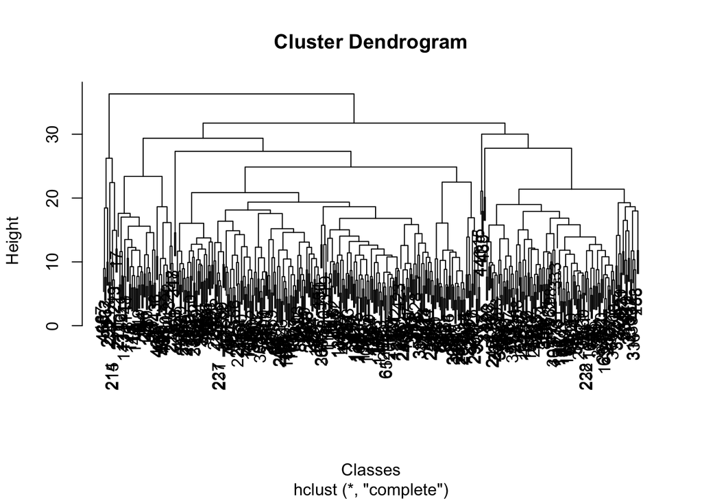

```r
plot(hier_clus_euc, xlab="Classes")
```

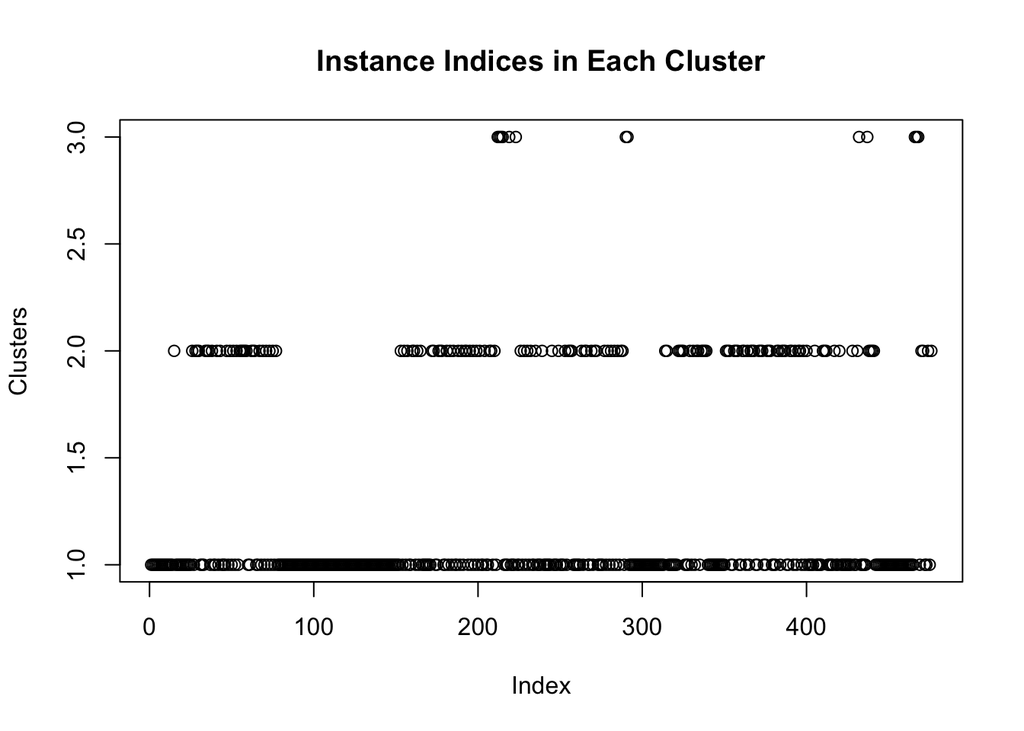

```r
model_euc<-cutree(hier_clus_euc, k = 3)
#model_euc
plot(model_euc, ylab="Clusters", main="Instance Indices in Each Cluster")
```

Instead of trying to find the centroid instance in each cluster, I found the center by averaging the instances. Then I calculated the distances of each instance to those 3 centers. As the next step, I averaged the distances for each bag to get bag representation table.

```r
euc_1<-scaled_data[model_euc==1,]
c1med<-colMeans(euc_1)
euc_2<-scaled_data[model_euc==2,]
c2med<-colMeans(euc_2)
euc_3<-scaled_data[model_euc==3,]
c3med<-colMeans(euc_3)
dis_euc<-rbind(scaled_data,c1med,c2med,c3med)
temp<-as.data.table(as.matrix(dist(dis_euc,method = "euclidean")))
temp<-temp[c(-477,-478,-479),c(477,478,479)]
table_hier_euc<-cbind(baginfo,temp)
```

```r
avg_table_hier_euc<-table_hier_euc[,.(C1=mean(c1med),C2=mean(c2med),C3=mean(c3med)),keyby=.(V2)]
bagclass<-baginfo[!duplicated(baginfo),]
avg_table_hier_euc<-cbind(bagclass$V1,avg_table_hier_euc)
setnames(avg_table_hier_euc,old=c("V1","V2"),new=c("BagClass","BagID"))
```

### Manhattan Case

The same procedure is applied here. K is chosen as 4.

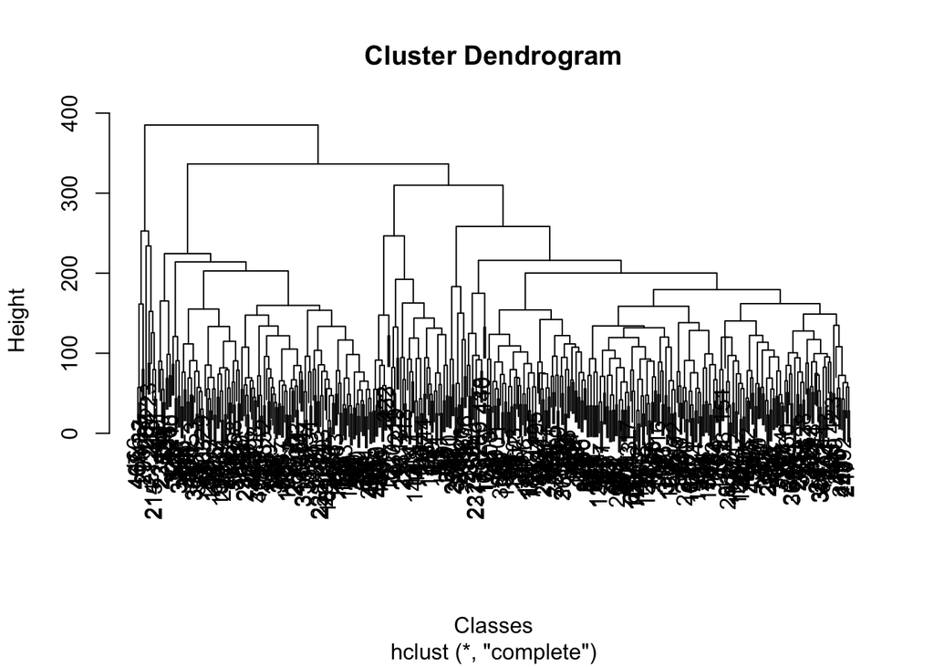

```r
hier_clus_man<-hclust(dist(scaled_data,"manhattan"),method="centroid")
#bad
hier_clus_man<-hclust(dist(scaled_data,"manhattan"),method="complete")
plot(hier_clus_man, xlab="Classes")
```

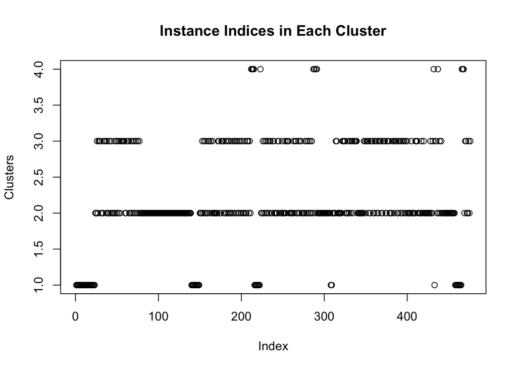

```r
model_man<-cutree(hier_clus_man, k = 4)
#model_man
plot(model_man, ylab="Clusters",main="Instance Indices in Each Cluster")
```

```r
man_1<-scaled_data[model_man==1,]
c1med<-colMeans(man_1)
man_2<-scaled_data[model_man==2,]
c2med<-colMeans(man_2)
man_3<-scaled_data[model_man==3,]
c3med<-colMeans(man_3)
man_4<-scaled_data[model_man==4,]
c4med<-colMeans(man_4)
dis_man<-rbind(scaled_data,c1med,c2med,c3med,c4med)
temp<-as.data.table(as.matrix(dist(dis_man,method = "manhattan")))
temp<-temp[c(-477,-478,-479,-480),c(477,478,479,480)]
table_hier_man<-cbind(baginfo,temp)
```

```r
avg_table_hier_man<-table_hier_man[,.(C1=mean(c1med),C2=mean(c2med),C3=mean(c3med),C4=mean(c4med)),keyby=.(V2)]
bagclass<-baginfo[!duplicated(baginfo),]
avg_table_hier_man<-cbind(bagclass$V1,avg_table_hier_man)
setnames(avg_table_hier_man,old=c("V1","V2"),new=c("BagClass","BagID"))
```

## Logistic Regression K-Medoids Euclidean Case (k=6)

As the final step, lasso logistic regression modelmis trained on the bag-level representation for classifying the bags. 10-fold cross-validation is applied on the training set which in this case is the whole data set. I did not split the data since we are not asked to record the performance on the test set.

```r
train_features<-avg_table_med_euc[,c(-1,-2)]
train_features_target<-as.factor(avg_table_med_euc$BagClass)
set.seed(1)
nofReplications<-1
nFolds<-10
indices=generateCVRuns(train_features_target,nofReplications,nFolds,stratified=TRUE)
```

Below, lambda sequence is generated.

```r
glm_train_data<-train_features
glmnet_alldata = glmnet(as.matrix(glm_train_data),train_features_target, family="binomial", alpha = 1, nlambda=50,standardize = TRUE)
lambda_sequence = glmnet_alldata$lambda
```

For each fold and lambda value, predictions and real classes are stored in cvresult table.

```r
cvresult=vector('list',nofReplications*nFolds)
iter=1

for(i in 1:nofReplications) {
  thisReplication=indices[[i]]
  for(j in 1:nFolds){
    testindices=(thisReplication[[j]])

    cvtrain=glm_train_data[-testindices]
    cvtrainclass=train_features_target[-testindices]
    cvtest=glm_train_data[testindices]
    cvtestclass=train_features_target[testindices]

    inner_cv_glmnet_fit = glmnet(as.matrix(cvtrain),as.factor(cvtrainclass),family="binomial", alpha = 1,lambda=lambda_sequence,standardize = TRUE)
    valid_pred = predict(inner_cv_glmnet_fit, as.matrix(cvtest), s = lambda_sequence, type = "response")

    foldresult=rbindlist(lapply(c(1:length(lambda_sequence)),function(x) { data.table(repl=i,fold=j,lambda=lambda_sequence[x],valid_pred[,x],result=cvtestclass)}))
    cvresult[[iter]]=foldresult
    iter=iter+1
  }
}

cvresult=rbindlist(cvresult)
cvresultcopy<-cvresult
```

AUC values are calculated for each fold and for each lambda.

```r
aucresult<-data.table()
for(i in 1:368){
  tempauc<-cvresultcopy[1:10,]
  predROC=prediction(tempauc$V4,tempauc$result)
  perf=performance(predROC,"tpr","fpr")
  auc<-as.numeric(performance(predROC,"auc")@y.values)
  aucresult<-rbind(aucresult,data.table(Replication=tempauc[1,1],Fold=tempauc[1,2],Lambda=tempauc[1,3],AUC=auc))
  cvresultcopy<-cvresultcopy[-(1:10),]
}

final<-aucresult[,.(Mean_AUC=mean(AUC)),keyby=.(Lambda.lambda)]

(cv_lambda_max=final[which.max(Mean_AUC)]$Lambda.lambda)
```

```
## [1] 0.0001402505
```

```r
(cv_auc_max=final[which.max(Mean_AUC)]$Mean_AUC)
```

```
## [1] 0.94
```

The lambda value that gives the highest AUC value is 0.0001402505. The AUC performance on the cross-validated training set is 0.94.

## Logistic Regression K-Medoids Manhattan Case (k=7)

The same procedure is applied here:

```r
train_features<-avg_table_med_man[,c(-1,-2)]
train_features_target<-as.factor(avg_table_med_man$BagClass)

set.seed(1)
nofReplications<-1
nFolds<-10
indices=generateCVRuns(train_features_target,nofReplications,nFolds,stratified=TRUE)
```

```r
glm_train_data<-train_features
glmnet_alldata = glmnet(as.matrix(glm_train_data),train_features_target, family="binomial", alpha = 1, nlambda=47,standardize = TRUE)
lambda_sequence = glmnet_alldata$lambda
```

```r
cvresult=vector('list',nofReplications*nFolds)
iter=1

for(i in 1:nofReplications) {
  thisReplication=indices[[i]]
  for(j in 1:nFolds){
    testindices=(thisReplication[[j]])

    cvtrain=glm_train_data[-testindices]
    cvtrainclass=train_features_target[-testindices]
    cvtest=glm_train_data[testindices]
    cvtestclass=train_features_target[testindices]

    inner_cv_glmnet_fit = glmnet(as.matrix(cvtrain),as.factor(cvtrainclass),family="binomial", alpha = 1,lambda=lambda_sequence,standardize = TRUE)
    valid_pred = predict(inner_cv_glmnet_fit, as.matrix(cvtest), s = lambda_sequence, type = "response")

    foldresult=rbindlist(lapply(c(1:length(lambda_sequence)),function(x) { data.table(repl=i,fold=j,lambda=lambda_sequence[x],valid_pred[,x],result=cvtestclass)}))
    cvresult[[iter]]=foldresult
    iter=iter+1
  }
}

cvresult=rbindlist(cvresult)
cvresultcopy<-cvresult
```

```r
aucresult<-data.table()
for(i in 1:368){
  tempauc<-cvresultcopy[1:10,]
  predROC=prediction(tempauc$V4,tempauc$result)
  perf=performance(predROC,"tpr","fpr")
  auc<-as.numeric(performance(predROC,"auc")@y.values)
  aucresult<-rbind(aucresult,data.table(Replication=tempauc[1,1],Fold=tempauc[1,2],Lambda=tempauc[1,3],AUC=auc))
  cvresultcopy<-cvresultcopy[-(1:10),]
}

final<-aucresult[,.(Mean_AUC=mean(AUC)),keyby=.(Lambda.lambda)]

(cv_lambda_max2=final[which.max(Mean_AUC)]$Lambda.lambda)
```

```
## [1] 0.004461673
```

```r
(cv_auc_max2=final[which.max(Mean_AUC)]$Mean_AUC)
```

```
## [1] 0.92
```

The lambda value that gives the highest AUC value is 0.004461673 The AUC performance on the cross-validated training set is 0.92.

## Logistic Regression Hierarchical Clustering Euclidean Case (k=3)

The same procedure is applied here:

```r
train_features<-avg_table_hier_euc[,c(-1,-2)]
train_features_target<-as.factor(avg_table_hier_euc$BagClass)
set.seed(1)
nofReplications<-1
nFolds<-10
indices=generateCVRuns(train_features_target,nofReplications,nFolds,stratified=TRUE)

glm_train_data<-train_features
glmnet_alldata = glmnet(as.matrix(glm_train_data),train_features_target, family="binomial", alpha = 1, nlambda=65,standardize = TRUE)
lambda_sequence = glmnet_alldata$lambda

cvresult=vector('list',nofReplications*nFolds)
iter=1

for(i in 1:nofReplications) {
  thisReplication=indices[[i]]
  for(j in 1:nFolds){
    testindices=(thisReplication[[j]])

    cvtrain=glm_train_data[-testindices]
    cvtrainclass=train_features_target[-testindices]
    cvtest=glm_train_data[testindices]
    cvtestclass=train_features_target[testindices]

    inner_cv_glmnet_fit = glmnet(as.matrix(cvtrain),as.factor(cvtrainclass),family="binomial", alpha = 1,lambda=lambda_sequence,standardize = TRUE)
    valid_pred = predict(inner_cv_glmnet_fit, as.matrix(cvtest), s = lambda_sequence, type = "response")

    foldresult=rbindlist(lapply(c(1:length(lambda_sequence)),function(x) { data.table(repl=i,fold=j,lambda=lambda_sequence[x],valid_pred[,x],result=cvtestclass)}))
    cvresult[[iter]]=foldresult
    iter=iter+1
  }
}

cvresult=rbindlist(cvresult)
cvresultcopy<-cvresult
aucresult<-data.table()
for(i in 1:368){
  tempauc<-cvresultcopy[1:10,]
  predROC=prediction(tempauc$V4,tempauc$result)
  perf=performance(predROC,"tpr","fpr")
  auc<-as.numeric(performance(predROC,"auc")@y.values)
  aucresult<-rbind(aucresult,data.table(Replication=tempauc[1,1],Fold=tempauc[1,2],Lambda=tempauc[1,3],AUC=auc))
  cvresultcopy<-cvresultcopy[-(1:10),]
}

final<-aucresult[,.(Mean_AUC=mean(AUC)),keyby=.(Lambda.lambda)]

(cv_lambda_max3=final[which.max(Mean_AUC)]$Lambda.lambda)
```

```
## [1] 0.0007942717
```

```r
(cv_auc_max3=final[which.max(Mean_AUC)]$Mean_AUC)
```

```
## [1] 0.82
```

The lambda value that gives the highest AUC value is 0.0007942717 The AUC performance on the cross-validated training set is 0.82.

## Logistic Regression Hierarchical Clustering Manhattan Case

```r
train_features<-avg_table_hier_man[,c(-1,-2)]
train_features_target<-as.factor(avg_table_hier_man$BagClass)

set.seed(1)
nofReplications<-1
nFolds<-10
indices=generateCVRuns(train_features_target,nofReplications,nFolds,stratified=TRUE)

glm_train_data<-train_features
glmnet_alldata = glmnet(as.matrix(glm_train_data),train_features_target, family="binomial", alpha = 1, nlambda=55,standardize = TRUE)
lambda_sequence = glmnet_alldata$lambda

cvresult=vector('list',nofReplications*nFolds)
iter=1

for(i in 1:nofReplications) {
  thisReplication=indices[[i]]
  for(j in 1:nFolds){
    testindices=(thisReplication[[j]])

    cvtrain=glm_train_data[-testindices]
    cvtrainclass=train_features_target[-testindices]
    cvtest=glm_train_data[testindices]
    cvtestclass=train_features_target[testindices]

    inner_cv_glmnet_fit = glmnet(as.matrix(cvtrain),as.factor(cvtrainclass),family="binomial", alpha = 1,lambda=lambda_sequence,standardize = TRUE)
    valid_pred = predict(inner_cv_glmnet_fit, as.matrix(cvtest), s = lambda_sequence, type = "response")

    foldresult=rbindlist(lapply(c(1:length(lambda_sequence)),function(x) { data.table(repl=i,fold=j,lambda=lambda_sequence[x],valid_pred[,x],result=cvtestclass)}))
    cvresult[[iter]]=foldresult
    iter=iter+1
  }
}

cvresult=rbindlist(cvresult)
cvresultcopy<-cvresult
aucresult<-data.table()
for(i in 1:368){
  tempauc<-cvresultcopy[1:10,]
  predROC=prediction(tempauc$V4,tempauc$result)
  perf=performance(predROC,"tpr","fpr")
  auc<-as.numeric(performance(predROC,"auc")@y.values)
  aucresult<-rbind(aucresult,data.table(Replication=tempauc[1,1],Fold=tempauc[1,2],Lambda=tempauc[1,3],AUC=auc))
  cvresultcopy<-cvresultcopy[-(1:10),]
}

final<-aucresult[,.(Mean_AUC=mean(AUC)),keyby=.(Lambda.lambda)]

(cv_lambda_max4=final[which.max(Mean_AUC)]$Lambda.lambda)
```

```
## [1] 0.0002433649
```

```r
(cv_auc_max4=final[which.max(Mean_AUC)]$Mean_AUC)
```

```
## [1] 0.94
```

The lambda value that gives the highest AUC value is 0.0002433649 The AUC performance on the cross-validated training set is 0.94.

In conclusion, the highest AUC value is achieved when:

1. K-medoids algorithm / Euclidean distance / 6 clusters
2. Hierarchical clustering / Manhattan distance / 4 clusters